# R Notebook

# 1. Introduction

```r
View(level_6r)
nrow(level_6r)
```

```
[1] 198
```

```r
ncol(level_6r)
```

```
[1] 1415
```

# 1.2. level_7r

species level data

```r
View(level_7r)
nrow(level_7r)
```

```
[1] 198
```

```r
ncol(level_7r)
```

```
[1] 3832
```

# 1.3. Packages

```r
library(tidyverse)
library(vegan)
library(dplyr)
library(ggplot2)
library(cowplot)
```

# 2. Task1. alpha diversity

alpha diversity=species diversity=샘플 “내” 다양성 species richness, species evenness 두 가지 측면으로 설명된다.

- chao1 : species richness, data의 가공이나 filetering을 어떻게 했는지에 따라 값이 크게 달라질 수 있다. shannon이나 simpson 사용이 좋아보인다.
- observed feature : taxa들의 수 세기
- shannon : 모든 종이 같은 비율을 가질 때 최대 값을 가진다. effect size가 작기 때문에 observed feature를 대신 사용하는 것도 방법이다.
- simpson : 랜덤하게 두 개의 sequences를 선택했을 때 둘이 서로 같은 종일 확률을 나타낸다. 0~1 사이의 값을 가진다.

R package 중 vegan 사용

shannon_index<-diversity(data, index=“shannon”) simpson_index<-deversity(data, index=“simpson”) observed feature<-specnumber(data)

```r
# level_6r preparation
level_6r$Shannon_Diversity <- NA
level_6r$Simpson_Diversity <- NA
level_6r$Species_Richness <- NA

for (i in 1:nrow(level_6r)) {
  level_6r$Shannon_Diversity[i] <- diversity(level_6r[i, 11:1415], index = "shannon")
  level_6r$Simpson_Diversity[i] <- diversity(level_6r[i, 11:1415], index = "simpson")
  level_6r$Species_Richness[i] <- specnumber(level_6r[i, 11:1415])
}

View(level_6r)

alpha_6r<-level_6r[,-c(11:1415)]
View(alpha_6r)

# 0week alpha_6r

alpha_6r_0week <- alpha_6r |>
  filter(visit == "0week")

# 6week alpha_6r

alpha_6r_6week <- alpha_6r |>
  filter(visit == "6week")

# 12week alpha_6r

alpha_6r_12week <- alpha_6r |>
  filter(visit == "12week")
```

```r
# level_7r preparation

level_7r$Shannon_Diversity <- NA
level_7r$Simpson_Diversity <- NA
level_7r$Species_Richness <- NA

for (i in 1:nrow(level_7r)) {
  level_7r$Shannon_Diversity[i] <- diversity(level_7r[i, 11:3832], index = "shannon")
  level_7r$Simpson_Diversity[i] <- diversity(level_7r[i, 11:3832], index = "simpson")
  level_7r$Species_Richness[i] <- specnumber(level_7r[i, 11:3832])
}

View(level_7r)

alpha_7r<-level_7r[,-c(11:3832)]
View(alpha_7r)

# 0week alpha_7r

alpha_7r_0week <- alpha_7r |>
  filter(visit == "0week")

# 6week alpha_7r

alpha_7r_6week <- alpha_7r |>
  filter(visit == "6week")

# 12week alpha_7r

alpha_7r_12week <- alpha_7r |>
  filter(visit == "12week")
```

# 2.1 test group VS placebo group 0 week alpha diversity different

```r
# level_6r 0week alpha diversity
# shannon
shannon_placebo_6r_0week <- alpha_6r_0week$Shannon_Diversity[alpha_6r_0week$group == "placebo"]
shannon_test_6r_0week<-alpha_6r_0week$Shannon_Diversity[alpha_6r_0week$group == "test"]

p_shannon_6r_0week<-wilcox.test(shannon_placebo_6r_0week, shannon_test_6r_0week, paired = FALSE)$p.value

plot_shannon_6r_0week <- ggplot(alpha_6r_0week, aes(x = group, y = Shannon_Diversity, fill = group, color = group)) +
  geom_boxplot() +
  geom_point(position = position_jitter(width = 0.2), alpha = 0.6) +
  stat_summary(fun = mean, geom = "text", aes(label = sprintf("%.2f", ..y..)),
               vjust = -0.5, color = "black")+
  theme_minimal() +
  labs(title = paste("Genus_Shannon Index_0week","\n",sprintf("p = %.3f",p_shannon_6r_0week)),
       x = "Group",
       y = "Shannon Diversity Index") +
  scale_fill_manual(values = c("test"="cornflowerblue", "placebo"="orange")) +
  scale_color_manual(values = c("test"="navy", "placebo"="darkorange"))

#simpson
simpson_placebo_6r_0week <- alpha_6r_0week$Simpson_Diversity[alpha_6r_0week$group == "placebo"]
simpson_test_6r_0week<-alpha_6r_0week$Simpson_Diversity[alpha_6r_0week$group == "test"]

p_simpson_6r_0week<-wilcox.test(simpson_placebo_6r_0week, simpson_test_6r_0week, paired = FALSE)$p.value

plot_simpson_6r_0week <- ggplot(alpha_6r_0week, aes(x = group, y = Simpson_Diversity, fill = group, color = group)) +
  geom_boxplot() +
  geom_point(position = position_jitter(width = 0.2), alpha = 0.6) +
  stat_summary(fun = mean, geom = "text", aes(label = sprintf("%.2f", ..y..)),
               vjust = -0.5, color = "black")+
  theme_minimal() +
  labs(title = paste("Genus_Simpson Index_0week","\n",sprintf("p = %.3f",p_simpson_6r_0week)),
       x = "Group",
       y = "Simpson Diversity Index") +
  scale_fill_manual(values = c("test"="cornflowerblue", "placebo"="orange")) +
  scale_color_manual(values = c("test"="navy", "placebo"="darkorange"))


#richness
richness_placebo_6r_0week <- alpha_6r_0week$Species_Richness[alpha_6r_0week$group == "placebo"]
richness_test_6r_0week<-alpha_6r_0week$Species_Richness[alpha_6r_0week$group == "test"]

p_richness_6r_0week<-wilcox.test(richness_placebo_6r_0week, richness_test_6r_0week, paired = FALSE)$p.value
```

```
wilcox.test.default(richness_placebo_6r_0week, richness_test_6r_0week, 에서 경고가 발생했습니다 :
  tie가 있어 정확한 p값을 계산할 수 없습니다
```

```
as_grob.default(plot)에서 경고가 발생했습니다 :
  Cannot convert object of class character into a grob.
경고: Graphs cannot be vertically aligned unless the axis parameter is set. Placing graphs unaligned.
경고: Graphs cannot be horizontally aligned unless the axis parameter is set. Placing graphs unaligned.
```

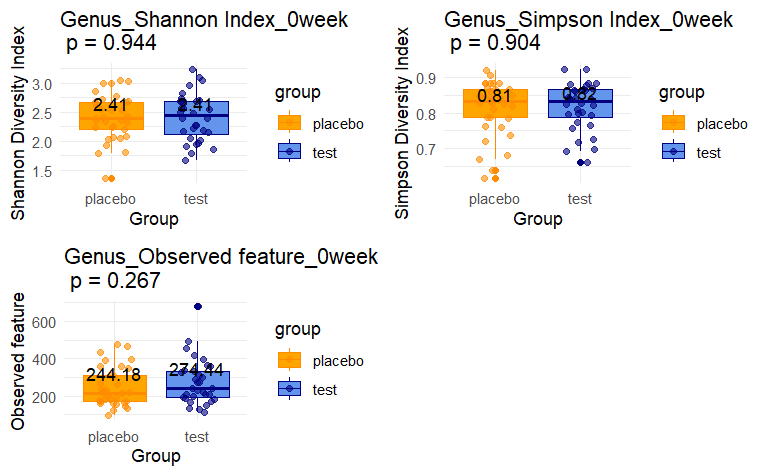

```r
plot_richness_6r_0week <- ggplot(alpha_6r_0week, aes(x = group, y = Species_Richness, fill = group, color = group)) +
  geom_boxplot() +
  geom_point(position = position_jitter(width = 0.2), alpha = 0.6) +
  stat_summary(fun = mean, geom = "text", aes(label = sprintf("%.2f", ..y..)),
               vjust = -0.5, color = "black")+
  theme_minimal() +
  labs(title = paste("Genus_Observed feature_0week","\n",sprintf("p = %.3f",p_richness_6r_0week)),
       x = "Group",
       y = "Observed feature") +
  scale_fill_manual(values = c("test"="cornflowerblue", "placebo"="orange")) +
  scale_color_manual(values = c("test"="navy", "placebo"="darkorange"))


plot_grid(
  plot_shannon_6r_0week, plot_simpson_6r_0week, plot_richness_6r_0week,
  labesl="AUTO",
  ncol=2,
  align="hv"
)
```

```r
# level_7r 0week alpha diverisity
# shannon
shannon_placebo_7r_0week <- alpha_7r_0week$Shannon_Diversity[alpha_7r_0week$group == "placebo"]
shannon_test_7r_0week<-alpha_7r_0week$Shannon_Diversity[alpha_7r_0week$group == "test"]

p_shannon_7r_0week<-wilcox.test(shannon_placebo_7r_0week, shannon_test_7r_0week, paired = FALSE)$p.value

plot_shannon_7r_0week <- ggplot(alpha_7r_0week, aes(x = group, y = Shannon_Diversity, fill = group, color = group)) +
  geom_boxplot() +
  geom_point(position = position_jitter(width = 0.2), alpha = 0.6) +
  stat_summary(fun = mean, geom = "text", aes(label = sprintf("%.2f", ..y..)),
               vjust = -0.5, color = "black")+
  theme_minimal() +
  labs(title = paste("Species_Shannon Index_0week","\n",sprintf("p = %.3f",p_shannon_7r_0week)),
       x = "Group",
       y = "Shannon Diversity Index") +
  scale_fill_manual(values = c("test"="cornflowerblue", "placebo"="orange")) +
  scale_color_manual(values = c("test"="navy", "placebo"="darkorange"))

#simpson
simpson_placebo_7r_0week <- alpha_7r_0week$Simpson_Diversity[alpha_7r_0week$group == "placebo"]
simpson_test_7r_0week<-alpha_7r_0week$Simpson_Diversity[alpha_7r_0week$group == "test"]

p_simpson_7r_0week<-wilcox.test(simpson_placebo_7r_0week, simpson_test_7r_0week, paired = FALSE)$p.value

plot_simpson_7r_0week <- ggplot(alpha_7r_0week, aes(x = group, y = Simpson_Diversity, fill = group, color = group)) +
  geom_boxplot() +
  geom_point(position = position_jitter(width = 0.2), alpha = 0.6) +
  stat_summary(fun = mean, geom = "text", aes(label = sprintf("%.2f", ..y..)),
               vjust = -0.5, color = "black")+
  theme_minimal() +
  labs(title = paste("Species_Simpson Index_0week","\n",sprintf("p = %.3f",p_simpson_7r_0week)),
       x = "Group",
       y = "Simpson Diversity Index") +
  scale_fill_manual(values = c("test"="cornflowerblue", "placebo"="orange")) +
  scale_color_manual(values = c("test"="navy", "placebo"="darkorange"))

#richness
richness_placebo_7r_0week <- alpha_7r_0week$Species_Richness[alpha_7r_0week$group == "placebo"]
richness_test_7r_0week<-alpha_7r_0week$Species_Richness[alpha_7r_0week$group == "test"]

p_richness_7r_0week<-wilcox.test(richness_placebo_7r_0week, richness_test_7r_0week, paired = FALSE)$p.value
```

```
wilcox.test.default(richness_placebo_7r_0week, richness_test_7r_0week, 에서 경고가 발생했습니다 :
  tie가 있어 정확한 p값을 계산할 수 없습니다
```

```
as_grob.default(plot)에서 경고가 발생했습니다 :
  Cannot convert object of class character into a grob.
경고: Graphs cannot be vertically aligned unless the axis parameter is set. Placing graphs unaligned.
경고: Graphs cannot be horizontally aligned unless the axis parameter is set. Placing graphs unaligned.
```

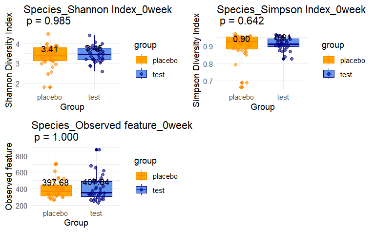

```r
plot_richness_7r_0week <- ggplot(alpha_7r_0week, aes(x = group, y = Species_Richness, fill = group, color = group)) +
  geom_boxplot() +
  geom_point(position = position_jitter(width = 0.2), alpha = 0.6) +
  stat_summary(fun = mean, geom = "text", aes(label = sprintf("%.2f", ..y..)),
               vjust = -0.5, color = "black")+
  theme_minimal() +
  labs(title = paste("Species_Observed feature_0week","\n",sprintf("p = %.3f",p_richness_7r_0week)),
       x = "Group",
       y = "Observed feature") +
  scale_fill_manual(values = c("test"="cornflowerblue", "placebo"="orange")) +
  scale_color_manual(values = c("test"="navy", "placebo"="darkorange"))

plot_grid(
  plot_shannon_7r_0week, plot_simpson_7r_0week, plot_richness_7r_0week,
  labesl="AUTO",
  ncol=2,
  align="hv"
)
```

# 2.2 test group VS placebo group 6 week alpha diversity different

```r
# level_6r 6week alpha diversity
# shannon
shannon_placebo_6r_6week <- alpha_6r_6week$Shannon_Diversity[alpha_6r_6week$group == "placebo"]
shannon_test_6r_6week<-alpha_6r_6week$Shannon_Diversity[alpha_6r_6week$group == "test"]

p_shannon_6r_6week<-wilcox.test(shannon_placebo_6r_6week, shannon_test_6r_6week, paired = FALSE)$p.value

plot_shannon_6r_6week <- ggplot(alpha_6r_6week, aes(x = group, y = Shannon_Diversity, fill = group, color = group)) +
  geom_boxplot() +
  geom_point(position = position_jitter(width = 0.2), alpha = 0.6) +
  stat_summary(fun = mean, geom = "text", aes(label = sprintf("%.2f", ..y..)),
               vjust = -0.5, color = "black")+
  theme_minimal() +
  labs(title = paste("Genus_Shannon Index_0week","\n",sprintf("p = %.3f",p_shannon_6r_6week)),
       x = "Group",
       y = "Shannon Diversity Index") +
  scale_fill_manual(values = c("test"="cornflowerblue", "placebo"="orange")) +
  scale_color_manual(values = c("test"="navy", "placebo"="darkorange"))

#simpson
simpson_placebo_6r_6week <- alpha_6r_6week$Simpson_Diversity[alpha_6r_6week$group == "placebo"]
simpson_test_6r_6week<-alpha_6r_6week$Simpson_Diversity[alpha_6r_6week$group == "test"]

p_simpson_6r_6week<-wilcox.test(simpson_placebo_6r_6week, simpson_test_6r_6week, paired = FALSE)$p.value


plot_simpson_6r_6week <- ggplot(alpha_6r_6week, aes(x = group, y = Simpson_Diversity, fill = group, color = group)) +
  geom_boxplot() +
  geom_point(position = position_jitter(width = 0.2), alpha = 0.6) +
  stat_summary(fun = mean, geom = "text", aes(label = sprintf("%.2f", ..y..)),
               vjust = -0.5, color = "black")+
  theme_minimal() +
  labs(title = paste("Genus_Simpson Index_0week","\n",sprintf("p = %.3f",p_simpson_6r_6week)),
       x = "Group",
       y = "Simpson Diversity Index") +
  scale_fill_manual(values = c("test"="cornflowerblue", "placebo"="orange")) +
  scale_color_manual(values = c("test"="navy", "placebo"="darkorange"))

#richness
richness_placebo_6r_6week <- alpha_6r_6week$Species_Richness[alpha_6r_6week$group == "placebo"]
richness_test_6r_6week<-alpha_6r_6week$Species_Richness[alpha_6r_6week$group == "test"]

p_richness_6r_6week<-wilcox.test(richness_placebo_6r_6week, richness_test_6r_6week, paired = FALSE)$p.value
```

```
wilcox.test.default(richness_placebo_6r_6week, richness_test_6r_6week, 에서 경고가 발생했습니다 :
  tie가 있어 정확한 p값을 계산할 수 없습니다
```

```
as_grob.default(plot)에서 경고가 발생했습니다 :
  Cannot convert object of class character into a grob.
경고: Graphs cannot be vertically aligned unless the axis parameter is set. Placing graphs unaligned.
경고: Graphs cannot be horizontally aligned unless the axis parameter is set. Placing graphs unaligned.
```

[figure not shown]

```r
plot_richness_6r_6week <- ggplot(alpha_6r_6week, aes(x = group, y = Species_Richness, fill = group, color = group)) +
  geom_boxplot() +
  geom_point(position = position_jitter(width = 0.2), alpha = 0.6) +
  stat_summary(fun = mean, geom = "text", aes(label = sprintf("%.2f", ..y..)),
               vjust = -0.5, color = "black")+
  theme_minimal() +
  labs(title = paste("Genus_Observed feature_0week","\n",sprintf("p = %.3f",p_richness_6r_6week)),
       x = "Group",
       y = "Observed feature") +
  scale_fill_manual(values = c("test"="cornflowerblue", "placebo"="orange")) +
  scale_color_manual(values = c("test"="navy", "placebo"="darkorange"))

plot_grid(
  plot_shannon_6r_6week, plot_simpson_6r_6week, plot_richness_6r_6week,
  labesl="AUTO",
  ncol=2,
  align="hv"
)
```

```r
#level_7r 6week alpha diversity
# shannon
shannon_placebo_7r_6week <- alpha_7r_6week$Shannon_Diversity[alpha_7r_6week$group == "placebo"]
shannon_test_7r_6week<-alpha_7r_6week$Shannon_Diversity[alpha_7r_6week$group == "test"]

p_shannon_7r_6week<-wilcox.test(shannon_placebo_7r_6week, shannon_test_7r_6week, paired = FALSE)$p.value

plot_shannon_7r_6week <- ggplot(alpha_7r_6week, aes(x = group, y = Shannon_Diversity, fill = group, color = group)) +
  geom_boxplot() +
  geom_point(position = position_jitter(width = 0.2), alpha = 0.6) +
  stat_summary(fun = mean, geom = "text", aes(label = sprintf("%.2f", ..y..)),
               vjust = -0.5, color = "black")+
  theme_minimal() +
  labs(title = paste("Species_Shannon Index_6week","\n",sprintf("p = %.3f",p_shannon_7r_6week)),
       x = "Group",
       y = "Shannon Diversity Index") +
  scale_fill_manual(values = c("test"="cornflowerblue", "placebo"="orange")) +
  scale_color_manual(values = c("test"="navy", "placebo"="darkorange"))

#simpson
simpson_placebo_7r_6week <- alpha_7r_6week$Simpson_Diversity[alpha_7r_6week$group == "placebo"]
simpson_test_7r_6week<-alpha_7r_6week$Simpson_Diversity[alpha_7r_6week$group == "test"]

p_simpson_7r_6week<-wilcox.test(simpson_placebo_7r_6week, simpson_test_7r_6week, paired = FALSE)$p.value

plot_simpson_7r_6week <- ggplot(alpha_7r_6week, aes(x = group, y = Simpson_Diversity, fill = group, color = group)) +
  geom_boxplot() +
  geom_point(position = position_jitter(width = 0.2), alpha = 0.6) +
  stat_summary(fun = mean, geom = "text", aes(label = sprintf("%.2f", ..y..)),
               vjust = -0.5, color = "black")+
  theme_minimal() +
  labs(title = paste("Species_Simpson Index_6week","\n",sprintf("p = %.3f",p_simpson_7r_6week)),
       x = "Group",
       y = "Simpson Diversity Index") +
  scale_fill_manual(values = c("test"="cornflowerblue", "placebo"="orange")) +
  scale_color_manual(values = c("test"="navy", "placebo"="darkorange"))

#richness
richness_placebo_7r_6week <- alpha_7r_6week$Species_Richness[alpha_7r_6week$group == "placebo"]
richness_test_7r_6week<-alpha_7r_6week$Species_Richness[alpha_7r_6week$group == "test"]

p_richness_7r_6week<-wilcox.test(richness_placebo_7r_6week, richness_test_7r_6week, paired = FALSE)$p.value
```

```
wilcox.test.default(richness_placebo_7r_6week, richness_test_7r_6week, 에서 경고가 발생했습니다 :
  tie가 있어 정확한 p값을 계산할 수 없습니다
```

```
as_grob.default(plot)에서 경고가 발생했습니다 :
  Cannot convert object of class character into a grob.
경고: Graphs cannot be vertically aligned unless the axis parameter is set. Placing graphs unaligned.
경고: Graphs cannot be horizontally aligned unless the axis parameter is set. Placing graphs unaligned.
```

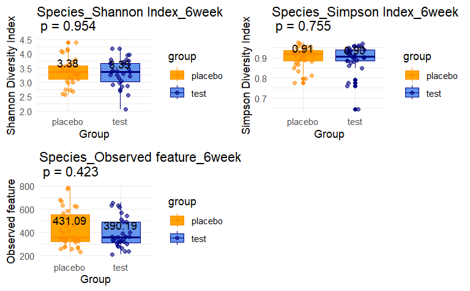

```r
plot_richness_7r_6week <- ggplot(alpha_7r_6week, aes(x = group, y = Species_Richness, fill = group, color = group)) +
  geom_boxplot() +
  geom_point(position = position_jitter(width = 0.2), alpha = 0.6) +
  stat_summary(fun = mean, geom = "text", aes(label = sprintf("%.2f", ..y..)),
               vjust = -0.5, color = "black")+
  theme_minimal() +
  labs(title = paste("Species_Observed feature_6week","\n",sprintf("p = %.3f",p_richness_7r_6week)),
       x = "Group",
       y = "Observed feature") +
  scale_fill_manual(values = c("test"="cornflowerblue", "placebo"="orange")) +
  scale_color_manual(values = c("test"="navy", "placebo"="darkorange"))

plot_grid(
  plot_shannon_7r_6week, plot_simpson_7r_6week, plot_richness_7r_6week,
  labesl="AUTO",
  ncol=2,
  align="hv"
)
```

# 2.3 test group VS placebo group 12 week alpha diversity different

```r
# level_6r 12week alpha diversity
# shannon
shannon_placebo_6r_12week <- alpha_6r_12week$Shannon_Diversity[alpha_6r_12week$group == "placebo"]
shannon_test_6r_12week<-alpha_6r_12week$Shannon_Diversity[alpha_6r_12week$group == "test"]

p_shannon_6r_12week<-wilcox.test(shannon_placebo_6r_12week, shannon_test_6r_12week, paired = FALSE)$p.value

plot_shannon_6r_12week <- ggplot(alpha_6r_12week, aes(x = group, y = Shannon_Diversity, fill = group, color = group)) +
  geom_boxplot() +
  geom_point(position = position_jitter(width = 0.2), alpha = 0.6) +
  stat_summary(fun = mean, geom = "text", aes(label = sprintf("%.2f", ..y..)),
               vjust = -0.5, color = "black")+
  theme_minimal() +
  labs(title = paste("Genus_Shannon Index_12week","\n",sprintf("p = %.3f",p_shannon_6r_12week)),
       x = "Group",
       y = "Shannon Diversity Index") +
  scale_fill_manual(values = c("test"="cornflowerblue", "placebo"="orange")) +
  scale_color_manual(values = c("test"="navy", "placebo"="darkorange"))

#simpson
simpson_placebo_6r_12week <- alpha_6r_12week$Simpson_Diversity[alpha_6r_12week$group == "placebo"]
simpson_test_6r_12week<-alpha_6r_12week$Simpson_Diversity[alpha_6r_12week$group == "test"]

p_simpson_6r_12week<-wilcox.test(simpson_placebo_6r_12week, simpson_test_6r_12week, paired = FALSE)$p.value

plot_simpson_6r_12week <- ggplot(alpha_6r_12week, aes(x = group, y = Simpson_Diversity, fill = group, color = group)) +
  geom_boxplot() +
  geom_point(position = position_jitter(width = 0.2), alpha = 0.6) +
  stat_summary(fun = mean, geom = "text", aes(label = sprintf("%.2f", ..y..)),
               vjust = -0.5, color = "black")+
  theme_minimal() +
  labs(title = paste("Genus_Simpson Index_12week","\n",sprintf("p = %.3f",p_simpson_6r_12week)),
       x = "Group",
       y = "Simpson Diversity Index") +
  scale_fill_manual(values = c("test"="cornflowerblue", "placebo"="orange")) +
  scale_color_manual(values = c("test"="navy", "placebo"="darkorange"))

#richness
richness_placebo_6r_12week <- alpha_6r_12week$Species_Richness[alpha_6r_12week$group == "placebo"]
richness_test_6r_12week<-alpha_6r_12week$Species_Richness[alpha_6r_12week$group == "test"]

p_richness_6r_12week<-wilcox.test(richness_placebo_6r_12week, richness_test_6r_12week, paired = FALSE)$p.value
```

```
wilcox.test.default(richness_placebo_6r_12week, richness_test_6r_12week, 에서 경고가 발생했습니다 :
  tie가 있어 정확한 p값을 계산할 수 없습니다
```

```
as_grob.default(plot)에서 경고가 발생했습니다 :
  Cannot convert object of class character into a grob.
경고: Graphs cannot be vertically aligned unless the axis parameter is set. Placing graphs unaligned.
경고: Graphs cannot be horizontally aligned unless the axis parameter is set. Placing graphs unaligned.
```

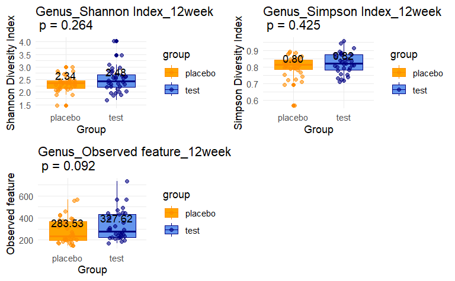

```r
plot_richness_6r_12week <- ggplot(alpha_6r_12week, aes(x = group, y = Species_Richness, fill = group, color = group)) +
  geom_boxplot() +
  geom_point(position = position_jitter(width = 0.2), alpha = 0.6) +
  stat_summary(fun = mean, geom = "text", aes(label = sprintf("%.2f", ..y..)),
               vjust = -0.5, color = "black")+
  theme_minimal() +
  labs(title = paste("Genus_Observed feature_12week","\n",sprintf("p = %.3f",p_richness_6r_12week)),
       x = "Group",
       y = "Observed feature") +
  scale_fill_manual(values = c("test"="cornflowerblue", "placebo"="orange")) +
  scale_color_manual(values = c("test"="navy", "placebo"="darkorange"))

plot_grid(
  plot_shannon_6r_12week, plot_simpson_6r_12week, plot_richness_6r_12week,
  labesl="AUTO",
  ncol=2,
  align="hv"
)
```

```r
# level_7r 12week alpha diversity
# shannon
shannon_placebo_7r_12week <- alpha_7r_12week$Shannon_Diversity[alpha_7r_12week$group == "placebo"]
shannon_test_7r_12week<-alpha_7r_12week$Shannon_Diversity[alpha_7r_12week$group == "test"]

p_shannon_7r_12week<-wilcox.test(shannon_placebo_7r_12week, shannon_test_7r_12week, paired = FALSE)$p.value

plot_shannon_7r_12week <- ggplot(alpha_7r_12week, aes(x = group, y = Shannon_Diversity, fill = group, color = group)) +
  geom_boxplot() +
  geom_point(position = position_jitter(width = 0.2), alpha = 0.6) +
  stat_summary(fun = mean, geom = "text", aes(label = sprintf("%.2f", ..y..)),
               vjust = -0.5, color = "black")+
  theme_minimal() +
  labs(title = paste("Species_Shannon Index_12week","\n",sprintf("p = %.3f",p_shannon_7r_12week)),
       x = "Group",
       y = "Shannon Diversity Index") +
  scale_fill_manual(values = c("test"="cornflowerblue", "placebo"="orange")) +
  scale_color_manual(values = c("test"="navy", "placebo"="darkorange"))

#simpson
simpson_placebo_7r_12week <- alpha_7r_12week$Simpson_Diversity[alpha_7r_12week$group == "placebo"]
simpson_test_7r_12week<-alpha_7r_12week$Simpson_Diversity[alpha_7r_12week$group == "test"]

p_simpson_7r_12week<-wilcox.test(simpson_placebo_7r_12week, simpson_test_7r_12week, paired = FALSE)$p.value

plot_simpson_7r_12week <- ggplot(alpha_7r_12week, aes(x = group, y = Simpson_Diversity, fill = group, color = group)) +
  geom_boxplot() +
  geom_point(position = position_jitter(width = 0.2), alpha = 0.6) +
  stat_summary(fun = mean, geom = "text", aes(label = sprintf("%.2f", ..y..)),
               vjust = -0.5, color = "black")+
  theme_minimal() +
  labs(title = paste("Species_Simpson Index_12week","\n",sprintf("p = %.3f",p_simpson_7r_12week)),
       x = "Group",
       y = "Simpson Diversity Index") +
  scale_fill_manual(values = c("test"="cornflowerblue", "placebo"="orange")) +
  scale_color_manual(values = c("test"="navy", "placebo"="darkorange"))

#richness
richness_placebo_7r_12week <- alpha_7r_12week$Species_Richness[alpha_7r_12week$group == "placebo"]
richness_test_7r_12week<-alpha_7r_12week$Species_Richness[alpha_7r_12week$group == "test"]

p_richness_7r_12week<-wilcox.test(richness_placebo_7r_12week, richness_test_7r_12week, paired = FALSE)$p.value
```

```
wilcox.test.default(richness_placebo_7r_12week, richness_test_7r_12week, 에서 경고가 발생했습니다 :
  tie가 있어 정확한 p값을 계산할 수 없습니다
```

```
as_grob.default(plot)에서 경고가 발생했습니다 :
  Cannot convert object of class character into a grob.
경고: Graphs cannot be vertically aligned unless the axis parameter is set. Placing graphs unaligned.
경고: Graphs cannot be horizontally aligned unless the axis parameter is set. Placing graphs unaligned.
```

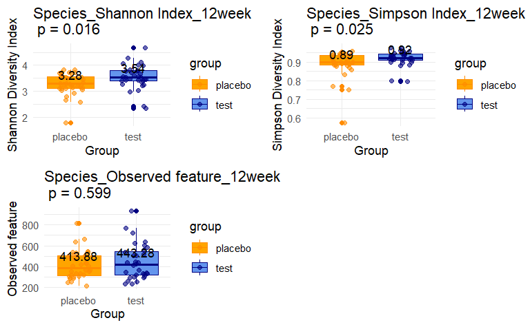

```r
plot_richness_7r_12week <- ggplot(alpha_7r_12week, aes(x = group, y = Species_Richness, fill = group, color = group)) +
  geom_boxplot() +
  geom_point(position = position_jitter(width = 0.2), alpha = 0.6) +
  stat_summary(fun = mean, geom = "text", aes(label = sprintf("%.2f", ..y..)),
               vjust = -0.5, color = "black")+
  theme_minimal() +
  labs(title = paste("Species_Observed feature_12week","\n",sprintf("p = %.3f",p_richness_7r_12week)),
       x = "Group",
       y = "Observed feature") +
  scale_fill_manual(values = c("test"="cornflowerblue", "placebo"="orange")) +
  scale_color_manual(values = c("test"="navy", "placebo"="darkorange"))

plot_grid(
  plot_shannon_7r_12week, plot_simpson_7r_12week, plot_richness_7r_12week,
  labesl="AUTO",
  ncol=2,
  align="hv"
)
```

# 2.4 thinking about..

# 3. Task2. beta diversity

beta diversity=ratio species diversity 샘플 “간” 다양성 Jaccard distance : 종의 존재유무 Bray-Curtis distance : 종의 총량, Abundance 고려 unweighted UniFrac distance : a qualitative measure of community dissimilarity that incorporates phylogenetic relationships between the features weighted UniFrac distance : a quantitative measure of community dissimilarity that incorporates phylogenetic relationships between the features

# 3.1 test group VS placebo group 0 week beta diversity different

```r
# level_6r 0week beta diversity
# bray

level_6r_0week <- level_6r|>
  filter(visit=="0week")

bray_dist_6r_0week<-vegdist(level_6r_0week[,c(11:1415)], method="bray")
bray_result_6r_0week <- cmdscale(bray_dist_6r_0week, eig = TRUE, k = 2)

bray_df_6r_0week <- data.frame(
  Sample = rownames(level_6r_0week),
  PC1 = bray_result_6r_0week$points[, 1],
  PC2 = bray_result_6r_0week$points[, 2],
  Group = level_6r_0week$group
)

eig_bray_6r_0week <- bray_result_6r_0week$eig / sum(bray_result_6r_0week$eig)

set.seed(123)
adonis_bray_6r_0week <- adonis2(bray_dist_6r_0week ~ level_6r_0week$group, permutations = 999)
bray_pvalue_6r_0week <- adonis_bray_6r_0week[1,"Pr(>F)"]
print(bray_pvalue_6r_0week)
```

```
[1] 0.689
```

```r
PCoA_bray_6r_0week<-ggplot(bray_df_6r_0week, aes(x = PC1, y = PC2, color = Group)) +
  geom_point(size = 1, alpha = 0.8) +
  theme_minimal() +
  labs(
    title = paste("Genus_Bray PCoA_0week","\n",sprintf("p = %.3f",bray_pvalue_6r_0week)),
    x = paste0("PC1 (", round(eig_bray_6r_0week[1] * 100, 1), "%)"),
    y = paste0("PC2 (", round(eig_bray_6r_0week[2] * 100, 1), "%)")
  ) +
  stat_ellipse(linetype="dashed")+
  theme(legend.position = "right")

#jaccard

jaccard_dist_6r_0week<-vegdist(level_6r_0week[,c(11:1415)], method="jaccard")
jaccard_result_6r_0week <- cmdscale(jaccard_dist_6r_0week, eig = TRUE, k = 2)

jaccard_df_6r_0week <- data.frame(
  Sample = rownames(level_6r_0week),
  PC1 = jaccard_result_6r_0week$points[, 1],
  PC2 = jaccard_result_6r_0week$points[, 2],
  Group = level_6r_0week$group
)

eig_jaccard_6r_0week <- jaccard_result_6r_0week$eig / sum(jaccard_result_6r_0week$eig)

set.seed(123)
adonis_jaccard_6r_0week <- adonis2(jaccard_dist_6r_0week ~ level_6r_0week$group, permutations = 999)
jaccard_pvalue_6r_0week <- adonis_jaccard_6r_0week[1,"Pr(>F)"]
print(jaccard_pvalue_6r_0week)
```

```
[1] 0.672
```

```
as_grob.default(plot)에서 경고가 발생했습니다 :
  Cannot convert object of class character into a grob.
```

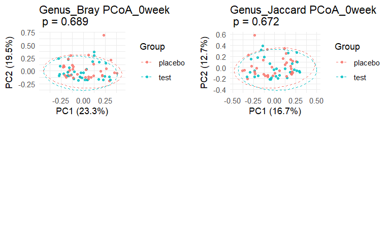

```r
PCoA_jaccard_6r_0week<-ggplot(jaccard_df_6r_0week, aes(x = PC1, y = PC2, color = Group)) +
  geom_point(size = 1, alpha = 0.8) +
  theme_minimal() +
  labs(
    title = paste("Genus_Jaccard PCoA_0week","\n",sprintf("p = %.3f", jaccard_pvalue_6r_0week)),
    x = paste0("PC1 (", round(eig_jaccard_6r_0week[1] * 100, 1), "%)"),
    y = paste0("PC2 (", round(eig_jaccard_6r_0week[2] * 100, 1), "%)")
  ) +
  stat_ellipse(linetype="dashed")+
  theme(legend.position = "right")

# 0week PCoA

plot_grid(
  PCoA_bray_6r_0week,PCoA_jaccard_6r_0week,
  labesl="AUTO",
  align="hv",
  axis = "tb"
)
```

```r
# level_7r 0week beta diversity
# bray

level_7r_0week <- level_7r|>
  filter(visit=="0week")

bray_dist_7r_0week<-vegdist(level_7r_0week[,c(11:3832)], method="bray")
bray_result_7r_0week <- cmdscale(bray_dist_7r_0week, eig = TRUE, k = 2)

bray_df_7r_0week <- data.frame(
  Sample = rownames(level_7r_0week),
  PC1 = bray_result_7r_0week$points[, 1],
  PC2 = bray_result_7r_0week$points[, 2],
  Group = level_7r_0week$group
)

eig_bray_7r_0week <- bray_result_7r_0week$eig / sum(bray_result_7r_0week$eig)

set.seed(123)
adonis_bray_7r_0week <- adonis2(bray_dist_7r_0week ~ level_7r_0week$group, permutations = 999)
bray_pvalue_7r_0week <- adonis_bray_7r_0week[1,"Pr(>F)"]
print(bray_pvalue_7r_0week)
```

```
[1] 0.824
```

```r
PCoA_bray_7r_0week<-ggplot(bray_df_7r_0week, aes(x = PC1, y = PC2, color = Group)) +
  geom_point(size = 1, alpha = 0.8) +
  theme_minimal() +
  labs(
    title = paste("Species_Bray PCoA_0week","\n",sprintf("p = %.3f",bray_pvalue_7r_0week)),
    x = paste0("PC1 (", round(eig_bray_7r_0week[1] * 100, 1), "%)"),
    y = paste0("PC2 (", round(eig_bray_7r_0week[2] * 100, 1), "%)")
  ) +
  stat_ellipse(linetype="dashed")+
  theme(legend.position = "right")

#jaccard

jaccard_dist_7r_0week<-vegdist(level_7r_0week[,c(11:3832)], method="jaccard")
jaccard_result_7r_0week <- cmdscale(jaccard_dist_7r_0week, eig = TRUE, k = 2)

jaccard_df_7r_0week <- data.frame(
  Sample = rownames(level_7r_0week),
  PC1 = jaccard_result_7r_0week$points[, 1],
  PC2 = jaccard_result_7r_0week$points[, 2],
  Group = level_7r_0week$group
)

eig_jaccard_7r_0week <- jaccard_result_7r_0week$eig / sum(jaccard_result_7r_0week$eig)

set.seed(123)
adonis_jaccard_7r_0week <- adonis2(jaccard_dist_7r_0week ~ level_7r_0week$group, permutations = 999)
jaccard_pvalue_7r_0week <- adonis_jaccard_7r_0week[1,"Pr(>F)"]
print(jaccard_pvalue_7r_0week)
```

```
[1] 0.807
```

```
as_grob.default(plot)에서 경고가 발생했습니다 :
  Cannot convert object of class character into a grob.
```

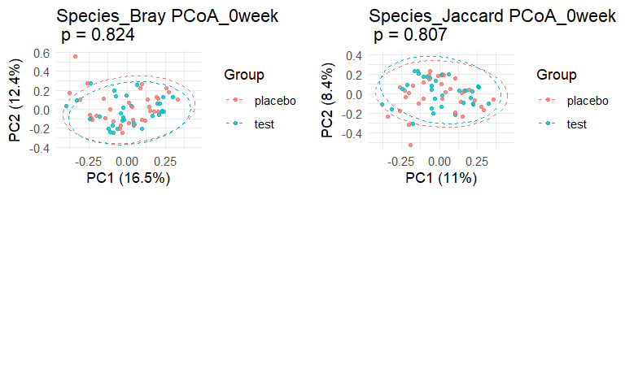

```r
PCoA_jaccard_7r_0week<-ggplot(jaccard_df_7r_0week, aes(x = PC1, y = PC2, color = Group)) +
  geom_point(size = 1, alpha = 0.8) +
  theme_minimal() +
  labs(
    title = paste("Species_Jaccard PCoA_0week","\n",sprintf("p = %.3f", jaccard_pvalue_7r_0week)),
    x = paste0("PC1 (", round(eig_jaccard_7r_0week[1] * 100, 1), "%)"),
    y = paste0("PC2 (", round(eig_jaccard_7r_0week[2] * 100, 1), "%)")
  ) +
  stat_ellipse(linetype="dashed")+
  theme(legend.position = "right")

# 0week PCoA

plot_grid(
  PCoA_bray_7r_0week,PCoA_jaccard_7r_0week,
  labesl="AUTO",
  align="hv",
  axis = "tb"
)
```

# 3.2 test group VS placebo group 6 week beta diversity different

```r
# level_6r 6week beta diversity

# bray

level_6r_6week <- level_6r|>
  filter(visit=="6week")

bray_dist_6r_6week<-vegdist(level_6r_6week[,c(11:1415)], method="bray")
bray_result_6r_6week <- cmdscale(bray_dist_6r_6week, eig = TRUE, k = 2)

bray_df_6r_6week <- data.frame(
  Sample = rownames(level_6r_6week),
  PC1 = bray_result_6r_6week$points[, 1],
  PC2 = bray_result_6r_6week$points[, 2],
  Group = level_6r_6week$group
)

eig_bray_6r_6week <- bray_result_6r_6week$eig / sum(bray_result_6r_6week$eig)

set.seed(123)
adonis_bray_6r_6week <- adonis2(bray_dist_6r_6week ~ level_6r_6week$group, permutations = 999)
bray_pvalue_6r_6week <- adonis_bray_6r_6week[1,"Pr(>F)"]
print(bray_pvalue_6r_6week)
```

```
[1] 0.712
```

```r
PCoA_bray_6r_6week<-ggplot(bray_df_6r_6week, aes(x = PC1, y = PC2, color = Group)) +
  geom_point(size = 1, alpha = 0.8) +
  theme_minimal() +
  labs(
    title = paste("Genus_Bray PCoA_6week","\n",sprintf("p = %.3f",bray_pvalue_6r_6week)),
    x = paste0("PC1 (", round(eig_bray_6r_6week[1] * 100, 1), "%)"),
    y = paste0("PC2 (", round(eig_bray_6r_6week[2] * 100, 1), "%)")
  ) +
  stat_ellipse(linetype="dashed")+
  theme(legend.position = "right")

#jaccard

jaccard_dist_6r_6week<-vegdist(level_6r_6week[,c(11:1415)], method="jaccard")
jaccard_result_6r_6week <- cmdscale(jaccard_dist_6r_6week, eig = TRUE, k = 2)

jaccard_df_6r_6week <- data.frame(
  Sample = rownames(level_6r_6week),
  PC1 = jaccard_result_6r_6week$points[, 1],
  PC2 = jaccard_result_6r_6week$points[, 2],
  Group = level_6r_6week$group
)

eig_jaccard_6r_6week <- jaccard_result_6r_6week$eig / sum(jaccard_result_6r_6week$eig)

set.seed(123)
adonis_jaccard_6r_6week <- adonis2(jaccard_dist_6r_6week ~ level_6r_6week$group, permutations = 999)
jaccard_pvalue_6r_6week <- adonis_jaccard_6r_6week[1,"Pr(>F)"]
print(jaccard_pvalue_6r_6week)
```

```
[1] 0.718
```

```
as_grob.default(plot)에서 경고가 발생했습니다 :
  Cannot convert object of class character into a grob.
```

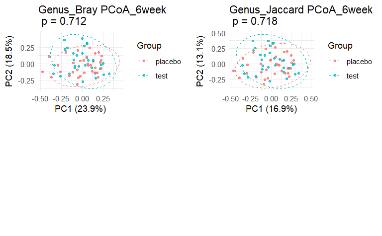

```r
PCoA_jaccard_6r_6week<-ggplot(jaccard_df_6r_6week, aes(x = PC1, y = PC2, color = Group)) +
  geom_point(size = 1, alpha = 0.8) +
  theme_minimal() +
  labs(
    title = paste("Genus_Jaccard PCoA_6week","\n",sprintf("p = %.3f", jaccard_pvalue_6r_6week)),
    x = paste0("PC1 (", round(eig_jaccard_6r_6week[1] * 100, 1), "%)"),
    y = paste0("PC2 (", round(eig_jaccard_6r_6week[2] * 100, 1), "%)")
  ) +
  stat_ellipse(linetype="dashed")+
  theme(legend.position = "right")

# 0week PCoA

plot_grid(
  PCoA_bray_6r_6week,PCoA_jaccard_6r_6week,
  labesl="AUTO",
  align="hv",
  axis = "tb"
)
```

```r
# level_7r 6week beta diversity

# bray

level_7r_6week <- level_7r|>
  filter(visit=="6week")

bray_dist_7r_6week<-vegdist(level_7r_6week[,c(11:3832)], method="bray")
bray_result_7r_6week <- cmdscale(bray_dist_7r_6week, eig = TRUE, k = 2)

bray_df_7r_6week <- data.frame(
  Sample = rownames(level_7r_6week),
  PC1 = bray_result_7r_6week$points[, 1],
  PC2 = bray_result_7r_6week$points[, 2],
  Group = level_7r_6week$group
)

eig_bray_7r_6week <- bray_result_7r_6week$eig / sum(bray_result_7r_6week$eig)

set.seed(123)
adonis_bray_7r_6week <- adonis2(bray_dist_7r_6week ~ level_7r_6week$group, permutations = 999)
bray_pvalue_7r_6week <- adonis_bray_7r_6week[1,"Pr(>F)"]
print(bray_pvalue_7r_6week)
```

```
[1] 0.538
```

```r
PCoA_bray_7r_6week<-ggplot(bray_df_7r_6week, aes(x = PC1, y = PC2, color = Group)) +
  geom_point(size = 1, alpha = 0.8) +
  theme_minimal() +
  labs(
    title = paste("Species_Bray PCoA_6week","\n",sprintf("p = %.3f",bray_pvalue_7r_6week)),
    x = paste0("PC1 (", round(eig_bray_7r_6week[1] * 100, 1), "%)"),
    y = paste0("PC2 (", round(eig_bray_7r_6week[2] * 100, 1), "%)")
  ) +
  stat_ellipse(linetype="dashed")+
  theme(legend.position = "right")

#jaccard

jaccard_dist_7r_6week<-vegdist(level_7r_6week[,c(11:3832)], method="jaccard")
jaccard_result_7r_6week <- cmdscale(jaccard_dist_7r_6week, eig = TRUE, k = 2)

jaccard_df_7r_6week <- data.frame(
  Sample = rownames(level_7r_6week),
  PC1 = jaccard_result_7r_6week$points[, 1],
  PC2 = jaccard_result_7r_6week$points[, 2],
  Group = level_7r_6week$group
)

eig_jaccard_7r_6week <- jaccard_result_7r_6week$eig / sum(jaccard_result_7r_6week$eig)

set.seed(123)
adonis_jaccard_7r_6week <- adonis2(jaccard_dist_7r_6week ~ level_7r_6week$group, permutations = 999)
jaccard_pvalue_7r_6week <- adonis_jaccard_7r_6week[1,"Pr(>F)"]
print(jaccard_pvalue_7r_6week)
```

```
[1] 0.533
```

```
as_grob.default(plot)에서 경고가 발생했습니다 :
  Cannot convert object of class character into a grob.
```

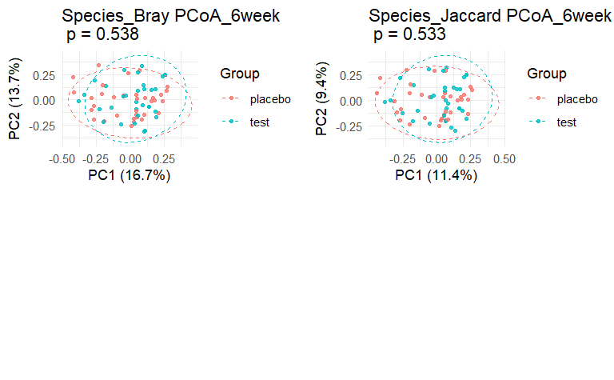

```r
PCoA_jaccard_7r_6week<-ggplot(jaccard_df_7r_6week, aes(x = PC1, y = PC2, color = Group)) +
  geom_point(size = 1, alpha = 0.8) +
  theme_minimal() +
  labs(
    title = paste("Species_Jaccard PCoA_6week","\n",sprintf("p = %.3f", jaccard_pvalue_7r_6week)),
    x = paste0("PC1 (", round(eig_jaccard_7r_6week[1] * 100, 1), "%)"),
    y = paste0("PC2 (", round(eig_jaccard_7r_6week[2] * 100, 1), "%)")
  ) +
  stat_ellipse(linetype="dashed")+
  theme(legend.position = "right")

# 6week PCoA

plot_grid(
  PCoA_bray_7r_6week,PCoA_jaccard_7r_6week,
  labesl="AUTO",
  align="hv",
  axis = "tb"
)
```

# 3.3 test group VS placebo group 12 week beta diversity different

```r
# level_6r 12week beta diversity

# bray

level_6r_12week <- level_6r|>
  filter(visit=="12week")

bray_dist_6r_12week<-vegdist(level_6r_12week[,c(11:1415)], method="bray")
bray_result_6r_12week <- cmdscale(bray_dist_6r_12week, eig = TRUE, k = 2)

bray_df_6r_12week <- data.frame(
  Sample = rownames(level_6r_12week),
  PC1 = bray_result_6r_12week$points[, 1],
  PC2 = bray_result_6r_12week$points[, 2],
  Group = level_6r_12week$group
)

eig_bray_6r_12week <- bray_result_6r_12week$eig / sum(bray_result_6r_12week$eig)

set.seed(123)
adonis_bray_6r_12week <- adonis2(bray_dist_6r_12week ~ level_6r_12week$group, permutations = 999)
bray_pvalue_6r_12week <- adonis_bray_6r_12week[1,"Pr(>F)"]
print(bray_pvalue_6r_12week)
```

```
[1] 0.144
```

```r
PCoA_bray_6r_12week<-ggplot(bray_df_6r_12week, aes(x = PC1, y = PC2, color = Group)) +
  geom_point(size = 1, alpha = 0.8) +
  theme_minimal() +
  labs(
    title = paste("Genus_Bray PCoA_12week","\n",sprintf("p = %.3f",bray_pvalue_6r_12week)),
    x = paste0("PC1 (", round(eig_bray_6r_12week[1] * 100, 1), "%)"),
    y = paste0("PC2 (", round(eig_bray_6r_12week[2] * 100, 1), "%)")
  ) +
  stat_ellipse(linetype="dashed")+
  theme(legend.position = "right")

#jaccard

jaccard_dist_6r_12week<-vegdist(level_6r_12week[,c(11:1415)], method="jaccard")
jaccard_result_6r_12week <- cmdscale(jaccard_dist_6r_12week, eig = TRUE, k = 2)

jaccard_df_6r_12week <- data.frame(
  Sample = rownames(level_6r_12week),
  PC1 = jaccard_result_6r_12week$points[, 1],
  PC2 = jaccard_result_6r_12week$points[, 2],
  Group = level_6r_12week$group
)

eig_jaccard_6r_12week <- jaccard_result_6r_12week$eig / sum(jaccard_result_6r_12week$eig)

set.seed(123)
adonis_jaccard_6r_12week <- adonis2(jaccard_dist_6r_12week ~ level_6r_12week$group, permutations = 999)
jaccard_pvalue_6r_12week <- adonis_jaccard_6r_12week[1,"Pr(>F)"]
print(jaccard_pvalue_6r_12week)
```

```
[1] 0.179
```

```
as_grob.default(plot)에서 경고가 발생했습니다 :
  Cannot convert object of class character into a grob.
```

[figure not shown]

```r
PCoA_jaccard_6r_12week<-ggplot(jaccard_df_6r_12week, aes(x = PC1, y = PC2, color = Group)) +
  geom_point(size = 1, alpha = 0.8) +
  theme_minimal() +
  labs(
    title = paste("Genus_Jaccard PCoA_6week","\n",sprintf("p = %.3f", jaccard_pvalue_6r_12week)),
    x = paste0("PC1 (", round(eig_jaccard_6r_12week[1] * 100, 1), "%)"),
    y = paste0("PC2 (", round(eig_jaccard_6r_12week[2] * 100, 1), "%)")
  ) +
  stat_ellipse(linetype="dashed")+
  theme(legend.position = "right")

# 12week PCoA

plot_grid(
  PCoA_bray_6r_12week,PCoA_jaccard_6r_12week,
  labesl="AUTO",
  align="hv",
  axis = "tb"
)
```

```r
# level_7r 6week beta diversity

# bray

level_7r_12week <- level_7r|>
  filter(visit=="12week")

bray_dist_7r_12week<-vegdist(level_7r_12week[,c(11:3832)], method="bray")
bray_result_7r_12week <- cmdscale(bray_dist_7r_12week, eig = TRUE, k = 2)

bray_df_7r_12week <- data.frame(
  Sample = rownames(level_7r_12week),
  PC1 = bray_result_7r_12week$points[, 1],
  PC2 = bray_result_7r_12week$points[, 2],
  Group = level_7r_12week$group
)

eig_bray_7r_12week <- bray_result_7r_12week$eig / sum(bray_result_7r_12week$eig)

set.seed(123)
adonis_bray_7r_12week <- adonis2(bray_dist_7r_12week ~ level_7r_12week$group, permutations = 999)
bray_pvalue_7r_12week <- adonis_bray_7r_12week[1,"Pr(>F)"]
print(bray_pvalue_7r_12week)
```

```
[1] 0.035
```

```r
PCoA_bray_7r_12week<-ggplot(bray_df_7r_12week, aes(x = PC1, y = PC2, color = Group)) +
  geom_point(size = 1, alpha = 0.8) +
  theme_minimal() +
  labs(
    title = paste("Species_Bray PCoA_12week","\n",sprintf("p = %.3f",bray_pvalue_7r_12week)),
    x = paste0("PC1 (", round(eig_bray_7r_12week[1] * 100, 1), "%)"),
    y = paste0("PC2 (", round(eig_bray_7r_12week[2] * 100, 1), "%)")
  ) +
  stat_ellipse(linetype="dashed")+
  theme(legend.position = "right")

#jaccard

jaccard_dist_7r_12week<-vegdist(level_7r_12week[,c(11:3832)], method="jaccard")
jaccard_result_7r_12week <- cmdscale(jaccard_dist_7r_12week, eig = TRUE, k = 2)

jaccard_df_7r_12week <- data.frame(
  Sample = rownames(level_7r_12week),
  PC1 = jaccard_result_7r_12week$points[, 1],
  PC2 = jaccard_result_7r_12week$points[, 2],
  Group = level_7r_12week$group
)

eig_jaccard_7r_12week <- jaccard_result_7r_12week$eig / sum(jaccard_result_7r_12week$eig)

set.seed(123)
adonis_jaccard_7r_12week <- adonis2(jaccard_dist_7r_12week ~ level_7r_12week$group, permutations = 999)
jaccard_pvalue_7r_12week <- adonis_jaccard_7r_12week[1,"Pr(>F)"]
print(jaccard_pvalue_7r_12week)
```

```
[1] 0.037
```

```
as_grob.default(plot)에서 경고가 발생했습니다 :
  Cannot convert object of class character into a grob.
```

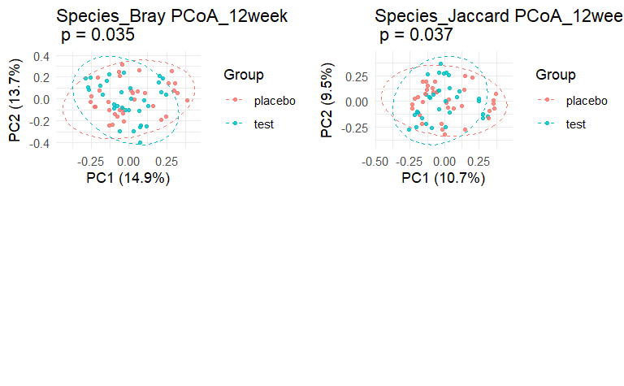

```r
PCoA_jaccard_7r_12week<-ggplot(jaccard_df_7r_12week, aes(x = PC1, y = PC2, color = Group)) +
  geom_point(size = 1, alpha = 0.8) +
  theme_minimal() +
  labs(
    title = paste("Species_Jaccard PCoA_12week","\n",sprintf("p = %.3f", jaccard_pvalue_7r_12week)),
    x = paste0("PC1 (", round(eig_jaccard_7r_12week[1] * 100, 1), "%)"),
    y = paste0("PC2 (", round(eig_jaccard_7r_12week[2] * 100, 1), "%)")
  ) +
  stat_ellipse(linetype="dashed")+
  theme(legend.position = "right")

# 0week PCoA

plot_grid(
  PCoA_bray_7r_12week,PCoA_jaccard_7r_12week,
  labesl="AUTO",
  align="hv",
  axis = "tb"
)
```

# 3.4 thinking about..

1. PCoA를 통해 비교 분석을 진행할 필요가 있음
2. PCoA 상에서 두 그룹간 비교를 위해 어떤 통계 방법을 적용해야 하는가
3. 이 결과를 어떻게 해석할 수 있는가

PERMANOVA 분석<-adonis2() 그래프에는 p-value를 포함해서 visualizaion 결과 해석은 p-value의 값이 0.05 큰지 작은지 대소 비교 0.05보다 크다<- 유의미한 차이가 없다. 0.05보다 작다<- 유의미한 차이가 있다.

# 4. chatGPT, Copliot 활용법 고안